# Assignment4

Garrett Nunn

December 4, 2018

## Question 2:

```r
set.seed(69)

x = c(rep("A",20), rep( "a",20))
pander = function(gen,p,q=1-p,w_AA,w_Aa,w_aa){
  result = integer(gen+1)
  result[1] = p
  for (i in 1:gen){
    wBar = (p^2)*w_AA+(2*p*q*w_Aa)+(q^2)*w_aa
    p = (p*p*w_AA/wBar)+(p*q*w_Aa/wBar)
    result[i+1]=p
  }
  if (p==1|p==0){
    print("It Fixed")
  }else{
    print("No fixation for you")
  }
  return(result)

}
UrTheBest =pander(100,0.95,0.5,1,0.01,0.01)
```

```
## [1] "No fixation for you"
```

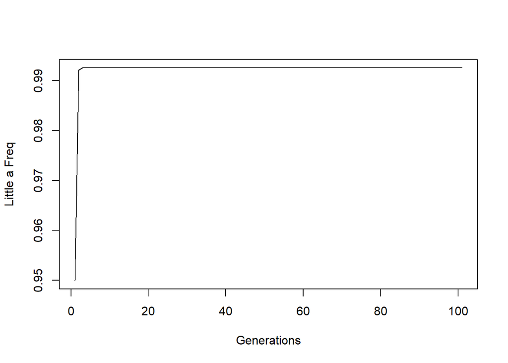

```r
plot(UrTheBest, type = "l", xlab = "Generations", ylab = "Little a Freq")
```

## Question 3:

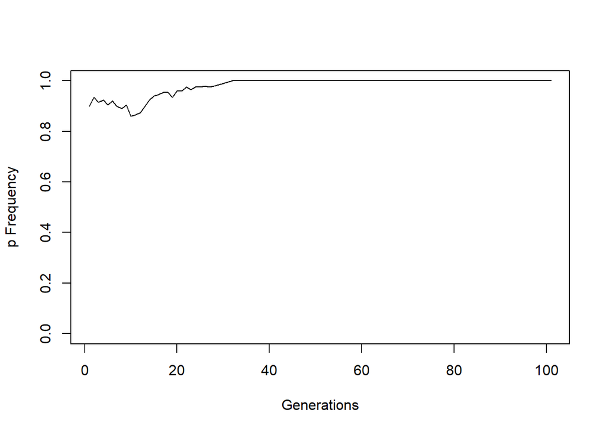

```r
genDriftSim = function(popSize,p,gen){
  y = c("A","a")
  pop = sample(y, size = popSize*2, replace =T, prob= c(p, 1-p))
  result = integer(gen+1)
  result[1]= p
  for (i in 1:gen){
    pop = sample(pop,size = popSize*2, replace = T)
    y = table(pop)[1]/(length(pop))
    if (names(y)=="a"){
      result[i+1] = 1-y
    } else{
      result[i+1] = 1
    }
  }
  plot(result, type = "l", xlab = "Generations", ylab = "p Frequency", ylim=c(0,1))
  return(result)
}
bestProfEver =genDriftSim(100,0.9,100)
```

## Question 4 and 5: **I accidentally did both question 4 and 5 at the same time as I thought that was what you were looking for. I would recommend not running 1000 runs as it might chug your computer (but it works!).**

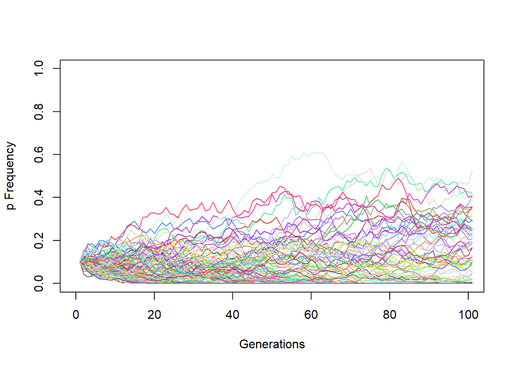

```
## [1] "Proportion lost: 0.54"
```

```r
genDriftSim = function(popSize,p,gen,colorMe =1){
  y = c("A","a")
  pop = sample(y, size = popSize*2, replace =T, prob= c(p, 1-p))
  result = integer(gen+1)
  result[1]= p
  for (i in 1:gen){
    pop = sample(pop,size = popSize*2, replace = T)
    y = table(pop)[1]/(length(pop))
    if (names(y)=="a"){
      result[i+1] = 1-y
    } else{
      result[i+1] = 1
    }
  }
  lines(result, col=colorMe)
  return(result[gen+1]==0)
}
library(randomcoloR)

wrapper = function(p,gen,popSize,n){
    palette <- distinctColorPalette(n)
    plot(0,0,type = "n", xlab = "Generations", ylab = "p Frequency", ylim=c(0,1),xlim =c(0,gen))
    x=0
    for(i in 1:n){
      x = x+genDriftSim(popSize,p,gen,palette[i])
    }
    paste("Proportion lost:",x/n)

  }
wrapper(0.1,100,200,100)
```

## Question 6:

```r
simpPA = function(int,slope,ss,rse){
  x <- seq(from =1, to = 10, length.out = ss) # length.out is how many observations we will have
  a <- int # intercept
  b <- slope # slope
  y_deterministic <- a + b*x

  y_simulated <- rnorm(length(x), mean = y_deterministic, sd = rse)
  mod_sim <- lm(y_simulated ~ x)
  p_val_slope <- summary(mod_sim)$coef[2,4] # extracts the p-value
  p_val_slope
}
simpPA(0.5,0.1,20,2)
```

```
## [1] 0.02779117
```

To check this code I would set the seed and run both codes to ensure they result in the same p-value additionally I could plot both sets of points and check they are identical

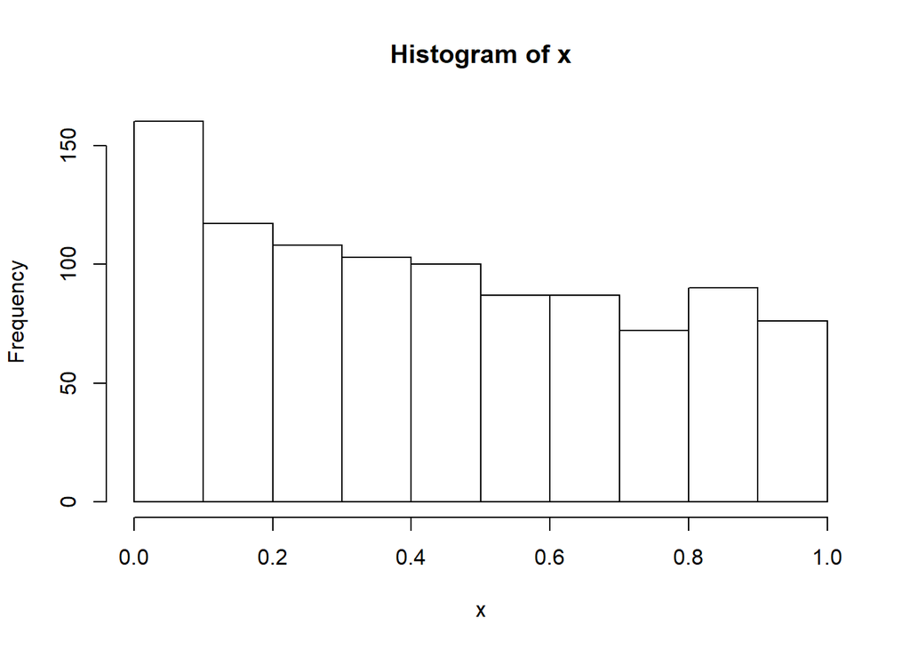

```r
x= integer(1000)
for (i in 1:1000){
  x[i]= simpPA(0.5,0.1,20,2)
}
hist(x)
```

```r
sum(x<0.05)/1000 #proportrion of p values less than 0.05
```

```
## [1] 0.095
```

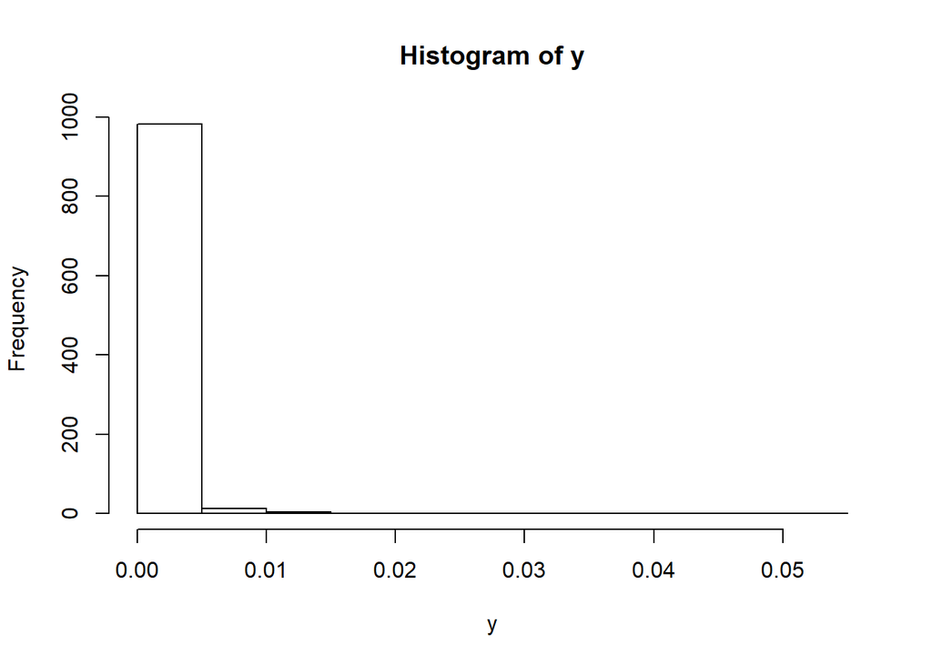

```r
y= integer(1000)
for (i in 1:1000){
  y[i]= simpPA(0.5,0.9,20,2)
}
hist(y)
```

```r
sum(y<0.05)/1000
```

```
## [1] 0.999
```

```r
  result=integer(19)
  for(z in 2:20){
    x= integer(1000)
    for (i in 1:1000){
      x[i]= simpPA(0.5,0.1,z*5,1.5)
    }
    result[z-1]=sum(x<0.05)/length(x)
  }
  result
```

```
##  [1] 0.079 0.087 0.116 0.167 0.138 0.149 0.185 0.219 0.222 0.266 0.282
## [12] 0.290 0.299 0.342 0.339 0.364 0.355 0.385 0.423
```

The larger the sample size the higher proportion of runs that have a p-value less than x. This makes sense as our generated data does have a correlation with x that’s value to defined by se and by increasing resolution (sample size) we are able to see more results that correlate with this. This is great up to a point when you are working with very very large data sets then there will be a ton of “significant” results when it could be just due to random chance.

## Extra: Fun Time Analysis :P

*This is a side thing I have constantly running for everything to make sure I am making best use of my time (as long as I actually analyze the data on phone)*

I spent ~ 3.5 hours on data camp * I was not going as fast as I could of as I let distractions get the better of me too often

I spent 2.5h on the questions * This was highly effective time spent * Question 6 took definitely the longest at around 40 minutes to parse through